# TransformationAxes Axes for Transformed Variables

Kevin O Brien

22 November 2018

#### Description

These functions produce axes for the original scale of transformed variables. Typically these would appear as additional axes to the right or at the top of the plot, but if the plot is produced with axes=FALSE, then these functions could be used for axes below or to the left of the plot as well.

#### Usage

```
basicPowerAxis(power, base=exp(1),
side=c("right", "above", "left", "below"),
at, start=0, lead.digits=1, n.ticks, grid=FALSE, grid.col=gray(0.50),
grid.lty=2, axis.title="Untransformed Data", cex=1, las=par("las"))

bcPowerAxis(power, side=c("right", "above", "left", "below"),
at, start=0, lead.digits=1, n.ticks, grid=FALSE, grid.col=gray(0.50),
grid.lty=2, axis.title="Untransformed Data", cex=1, las=par("las"))

bcnPowerAxis(power, shift, side=c("right", "above", "left", "below"),
at, start=0, lead.digits=1, n.ticks, grid=FALSE, grid.col=gray(0.50),
grid.lty=2, axis.title="Untransformed Data", cex=1, las=par("las"))

yjPowerAxis(power, side=c("right", "above", "left", "below"),
at, lead.digits=1, n.ticks, grid=FALSE, grid.col=gray(0.50),
grid.lty=2, axis.title="Untransformed Data", cex=1, las=par("las"))

probabilityAxis(scale=c("logit", "probit"),
side=c("right", "above", "left", "below"),
at, lead.digits=1, grid=FALSE, grid.lty=2, grid.col=gray(0.50),
axis.title = "Probability", interval = 0.1, cex = 1, las=par("las"))
```

#### Arguments

power power for Box-Cox, Box-Cox with negatives, Yeo-Johnson, or simple power transformation. shift the shift (gamma) parameter for the Box-Cox with negatives family. scale transformation used for probabilities, “logit” (the default) or “probit”. side side at which the axis is to be drawn; numeric codes are also permitted: side = 1 for the bottom of the plot, side=2 for the left side, side = 3 for the top, side = 4 for the right side. at numeric vector giving location of tick marks on original scale; if missing, the function will try to pick nice locations for the ticks. start if a start was added to a variable (e.g., to make all data values positive), it can now be subtracted from the tick labels. lead.digits number of leading digits for determining ‘nice’ numbers for tick labels (default is 1. n.ticks number of tick marks; if missing, same as corresponding transformed axis. grid if TRUE grid lines for the axis will be drawn. grid.col color of grid lines. grid.lty line type for grid lines. axis.title title for axis. cex relative character expansion for axis label. las if 0, ticks labels are drawn parallel to the axis; set to 1 for horizontal labels (see par). base base of log transformation for power.axis when power = 0. interval desired interval between tick marks on the probability scale.

#### References

Fox, J. and Weisberg, S. (2019) An R Companion to Applied Regression, Third Edition, Sage. See Also basicPower, bcPower, yjPower, logit.

#### Examples

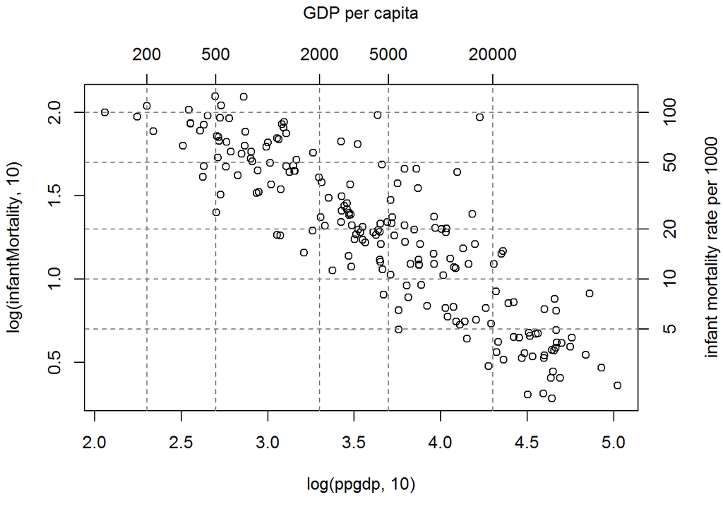

```r
UN <- na.omit(UN)
par(mar=c(5, 4, 4, 4) + 0.1) # leave space on right
with(UN, plot(log(ppgdp, 10), log(infantMortality, 10)))
basicPowerAxis(0, base=10, side="above",
at=c(50, 200, 500, 2000, 5000, 20000), grid=TRUE,
axis.title="GDP per capita")
basicPowerAxis(0, base=10, side="right",
at=c(5, 10, 20, 50, 100), grid=TRUE,
axis.title="infant mortality rate per 1000")
```

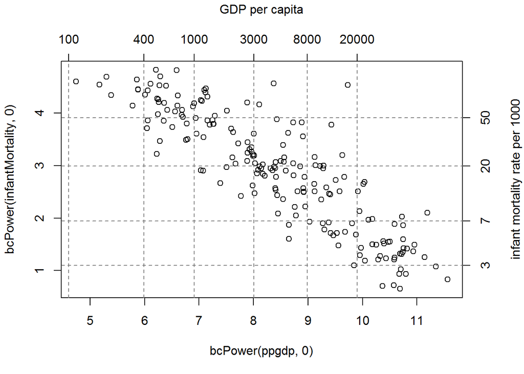

```r
with(UN, plot(bcPower(ppgdp, 0), bcPower(infantMortality, 0)))
bcPowerAxis(0, side="above",
grid=TRUE, axis.title="GDP per capita")
bcPowerAxis(0, side="right",
grid=TRUE, axis.title="infant mortality rate per 1000")
```

```r
with(UN, qqPlot(logit(infantMortality/1000)))
```

```
## [1] 155  75
```

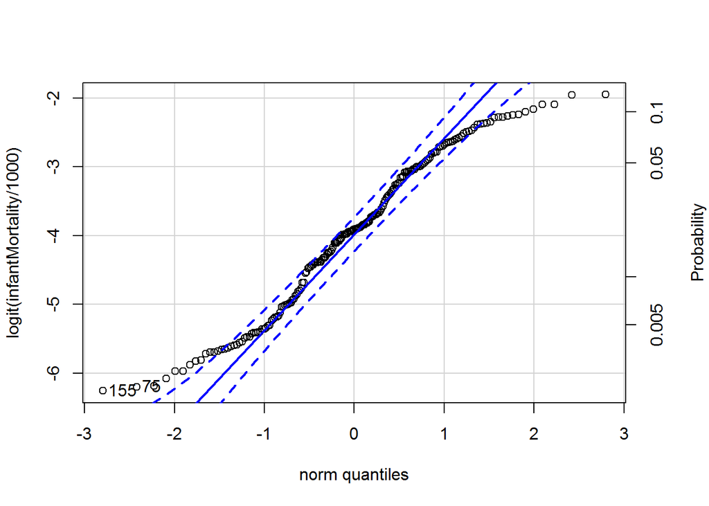

```r
probabilityAxis()
```

```r
with(UN, qqPlot(qnorm(infantMortality/1000)))
```

```
## [1]  1 33
```

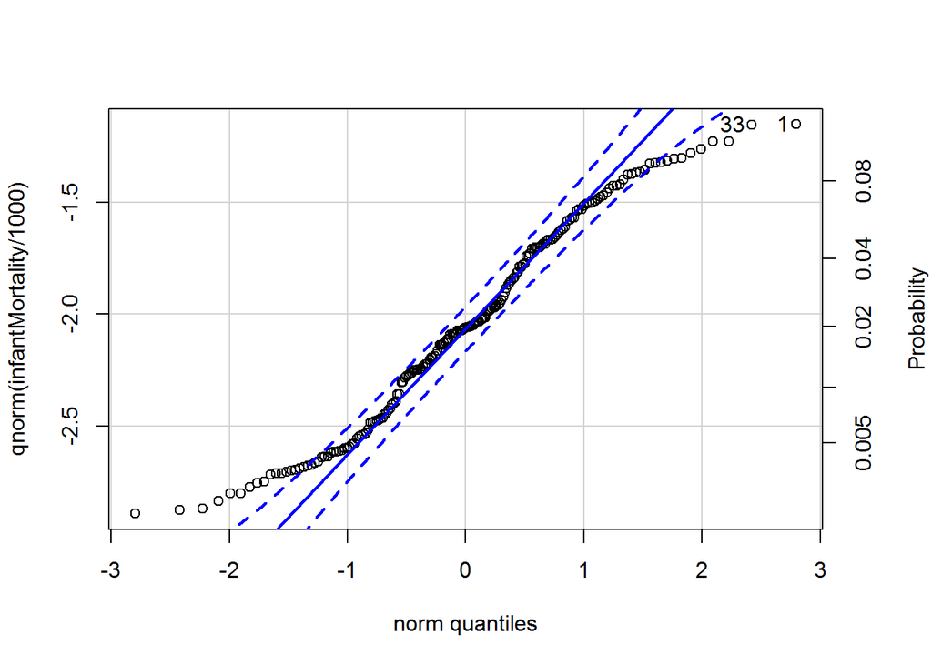

```r
probabilityAxis(at=c(.005, .01, .02, .04, .08, .16), scale="probit")
```

```r
qqPlot(bcnPower(Ornstein$interlocks, lambda=1/3, gamma=0.1))
```

```
## [1] 2 3
```

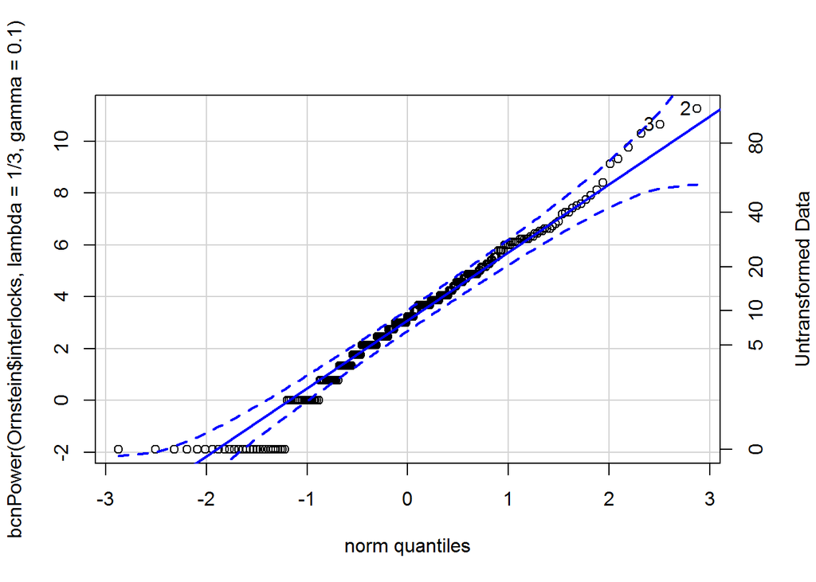

```r
bcnPowerAxis(1/3, 0.1, at=c(o=0, 5, 10, 20, 40, 80))
```